# Biometry-03

# Ha1: There is an interaction between factors Greenhouse and Soil.mix

```r
h5.p2.2way.aov_model1 <- aov(productivity~Greenhouse*Soil.mix,data = data2)
summary(h5.p2.2way.aov_model1)
```

```
##                      Df Sum Sq Mean Sq F value   Pr(>F)
## Greenhouse            4  297.5   74.39  23.896 2.65e-16 ***
## Soil.mix              2  176.3   88.16  28.320 1.29e-11 ***
## Greenhouse:Soil.mix   8   51.1    6.39   2.051    0.042 *
## Residuals           210  653.7    3.11
## ---
## Signif. codes:  0 '***' 0.001 '**' 0.01 '*' 0.05 '.' 0.1 ' ' 1
```

```r
res = h5.p2.2way.aov_model1$residuals

shapiro.test(h5.p2.2way.aov_model1$residuals)
```

```
##
##  Shapiro-Wilk normality test
##
## data:  h5.p2.2way.aov_model1$residuals
## W = 0.97556, p-value = 0.0006152
```

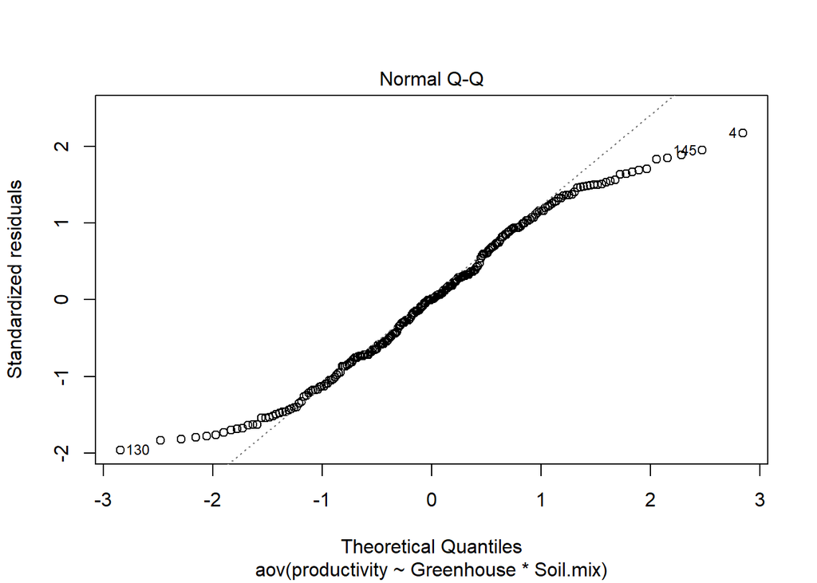

```r
plot(h5.p2.2way.aov_model1, 2)
```

```r
### Test for variences

leveneTest(productivity~Greenhouse*Soil.mix, data = data2)
```

```
## Levene's Test for Homogeneity of Variance (center = median)
##        Df F value  Pr(>F)
## group  14  2.1362 0.01131 *
##       210
## ---
## Signif. codes:  0 '***' 0.001 '**' 0.01 '*' 0.05 '.' 0.1 ' ' 1
```

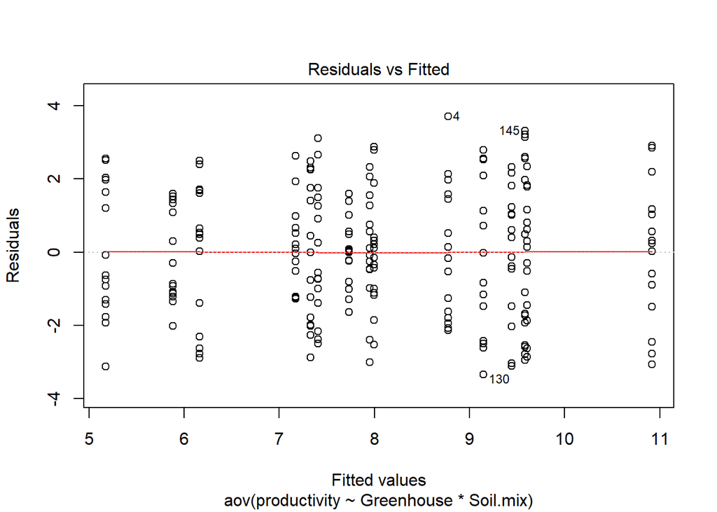

```r
plot(h5.p2.2way.aov_model1, 1)
```

## Data transform

```r
h5.p2.2way.aov_model1_log <- aov(log10(productivity)~Greenhouse*Soil.mix,data = data2)
summary(h5.p2.2way.aov_model1_log)
```

```
##                      Df Sum Sq Mean Sq F value   Pr(>F)
## Greenhouse            4 1.0381 0.25953  23.968 2.41e-16 ***
## Soil.mix              2 0.5549 0.27744  25.621 1.11e-10 ***
## Greenhouse:Soil.mix   8 0.2523 0.03154   2.912  0.00422 **
## Residuals           210 2.2740 0.01083
## ---
## Signif. codes:  0 '***' 0.001 '**' 0.01 '*' 0.05 '.' 0.1 ' ' 1
```

```r
res = h5.p2.2way.aov_model1_log$residuals
shapiro.test(h5.p2.2way.aov_model1_log$residuals)
```

```
##
##  Shapiro-Wilk normality test
##
## data:  h5.p2.2way.aov_model1_log$residuals
## W = 0.98091, p-value = 0.003909
```

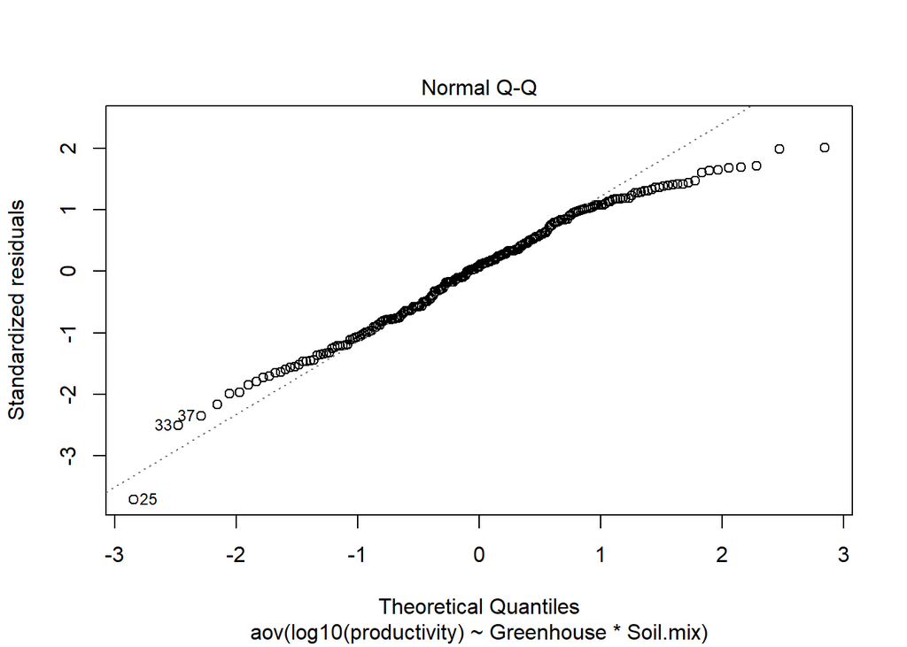

```r
plot(h5.p2.2way.aov_model1_log, 2)
```

```r
leveneTest(log10(productivity)~Greenhouse*Soil.mix, data = data2)
```

```
## Levene's Test for Homogeneity of Variance (center = median)
##        Df F value   Pr(>F)
## group  14  2.8108 0.000718 ***
##       210
## ---
## Signif. codes:  0 '***' 0.001 '**' 0.01 '*' 0.05 '.' 0.1 ' ' 1
```

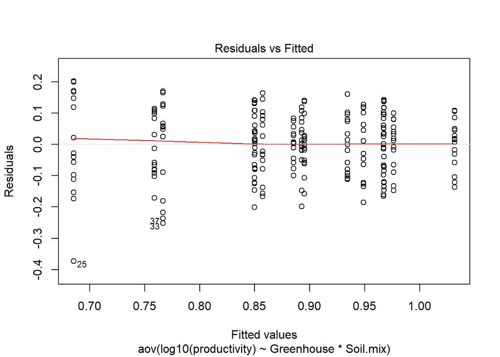

```r
plot(h5.p2.2way.aov_model1_log, 1)
```

Here, on both transformed and non transformed data Shapiro and levenes test failed to accept the NULL hypotheis. For the non tranformed data, shipiro test showed p value as 0.0006152 and levens test showed p value as 0.01131. On the transformed data, Shapiro test and levens test showed p value as 0.003909 and 0.000718.

```r
summary(h5.p2.2way.aov_model1)
```

```
##                      Df Sum Sq Mean Sq F value   Pr(>F)
## Greenhouse            4  297.5   74.39  23.896 2.65e-16 ***
## Soil.mix              2  176.3   88.16  28.320 1.29e-11 ***
## Greenhouse:Soil.mix   8   51.1    6.39   2.051    0.042 *
## Residuals           210  653.7    3.11
## ---
## Signif. codes:  0 '***' 0.001 '**' 0.01 '*' 0.05 '.' 0.1 ' ' 1
```

```r
summary(h5.p2.2way.aov_model1_log)
```

```
##                      Df Sum Sq Mean Sq F value   Pr(>F)
## Greenhouse            4 1.0381 0.25953  23.968 2.41e-16 ***
## Soil.mix              2 0.5549 0.27744  25.621 1.11e-10 ***
## Greenhouse:Soil.mix   8 0.2523 0.03154   2.912  0.00422 **
## Residuals           210 2.2740 0.01083
## ---
## Signif. codes:  0 '***' 0.001 '**' 0.01 '*' 0.05 '.' 0.1 ' ' 1
```

# Consluson:

### Problem 3:

The authors used four fenced exclosures of one-year and two within four-year burned watersheds that had been previously used to determine the effect of bison grazing on plant community structure. The authors used these as “paired” samples. In this way, they eventully had four conditions available to gather their data: annually burned and ungrazed, annually burned and grazed, burned every four years and ungrazed, and burned every four years and grazed.For these analyses data from the 12 small (0.25-m2) plots within a sampling unit, mean was calculated (except for PD and resource variability) and log-transformed when necessary to improve normality and homogeneity of variances. Their results show that grazing and annual burning had opposite effects on small-scale (0.25-m2) plant community structure.

The researchers employed mixed model ANOVA with the metrics of community structure and heterogeneity, resource availability,and the CVs for N and light availability as response variables, they had used this model as they treat the distance between the units was sufficient to ensure “independence with respect to responses to burning and grazing”, and the block design is a random nested factor.